# Análisis de datos ómicos (M0-157) Primera prueba de evaluación continua.

**Fecha de publicación del enunciado: 31/10/2022**

**Fecha límite para presentar la PEC: 16/11/2022**[^1]

# 1 Introducción

*La solución de la PEC tiene dos objetivos principales:* *- Por un lado, debe mostrar un modelo de “resolución” de las preguntas planteadas que sirva de ejemplo de como se podía haber resuelto las preguntas y de comparación con vuestra propia solución.* *- Además debe contener explicaciones sobre el desarrollo de la PEC, que, normalmente no formaran parte de un informe, como es el caso de esta introducción.* *Para hacerlo sencillo he dejado los comentarios, es decir nuestras opiniones o valoraciones. en cursiva y lo que es la solución estricta, es decir lo que debe parecerse a vuestra resolución, en formato normal.*

*Tal como se os pedía, el código no aparecerá dentro del texto, aunque con fines didácticos lo podréis mostrar cuando así lo deseéis. Esto se puede hacer con un simple comando de Rmarkdown*

*En este documento se presenta una solución tipo, es decir no se valoran todos los casos sino que se resuelve uno. Eventualmente se añadirán comentarios sobre aquellos datasets que puedan haber dado problemas o que tengan especificidades concretas.*

## 1.1 Objetivos

El objetivo principal de este trabajo es realizar un análisis exploratorio de unos datos de microarrays, descargados de la base de datos [Gene Expression Omnibus (GEO)](https://www.ncbi.nlm.nih.gov/geo/) utilizando el programa estadístico R y las librerías para análisis de datos ómicos integradas en Bioconductor. En concreto se requiere que los datos descargados se almacenen en un objeto de clase `ExpressionSet` y que se acceda a ellos a través de este objeto.

# 2 Materiales y Métodos

Los datos con los que se trabajará se descargarán de GEO utilizando el paquete [GEOquery](https://bioconductor.org/packages/release/bioc/html/GEOquery.html) de Bioconductor. Este paquete permite descargar los datos indicados (por un identificador GSE o GDS) y crear con ellos una estructura de datos del tipo `expressionSet` que contiene una matriz de datos preprocesados (habitualmente normalizados, así como una tabla con información sobre covariables y tras aspectos del experimento.

La exploración se llevará a cabo siguiendo la plantilla de un caso de estudio, Analisis_de_datos_omicos-Ejemplo_0-Microarrays y por lo tanto está relativamente bien pautada. Básicamente dicha exploración consistirá en: - Análisis univariante de los datos, mediante boxplots y/o histogramas para estudiar la forma general de los mismos. - Análisis multivariante de los datos, mediante Análisis de Componentes Principales y Agrupamiento Jerárquico, para determinar si los grupos que aparezcan (en caso de hacerlo) parecen relacionarse con las fuentes de variabilidad del estudio o, si por el contrario, podrían haber otras fuentes de variabilidad como efectos batch.

Las técnicas mencionadas son muy habituales en estadística y bioinformática por lo que no nos entretendremos en explicarlas. Pueden verse resumidas en los materiales de la asignatura (documento “Módulo 1. Preliminares”).

## 2.1 Selección de los datos para el estudio

Los datos para este estudio se han tenido que escoger de entre una lista de estudios depositados en GEO. Aunque es posible escoger el que se desee, evitando datasets problemáticos, una forma “neutra” de hacerlo es sorteando el identificador.

*El registro de la fila 27 da problemas al descargarlo por lo que se suprime*

```r
library(readxl)
GEOdat <- read_excel("GEOdatasets_updatedNov2022.xls")
GEOdat <- GEOdat[-27, ]
```

Fijamos una semilla para el generador interno de números aleatorios, lo que nos asegura que, mientras no la cambiemos, se repetirá la asignación del estudio.

```r
set.seed(234567)
seleccion <- sample(1:nrow(GEOdat), 1)
GEOSerie <- GEOdat[seleccion, 2]
GEODataset <- GEOdat[seleccion, 1]
```

*Para este estudio hemos seleccionado el resultado de la selección aleatoria, GSE3737.*

# 3 Resultados

## 3.1 Estructura de los datos y del estudio

### 3.1.1 Opción 1: Utilizar la clase `GDS` y trabajar con el resultado de descargar con el identificador `GDS`

Aunque podríamos trabajar únicamente con el objeto de clase “GDS” los utilizaremos ambos.

*Para este ejercicio utilizaremos el `ExpressionSet` obtenido a partir de la serie.*

```r
library(GEOquery)
myGSE <- getGEO(GEOSerie, AnnotGPL = TRUE)
myGDS <- getGEO(GEODataset, AnnotGPL = TRUE)
```

La clase ‘GDS’ contiene - información sobre el estudio en forma de metadatos que podemos utilizar para crear una tabla resumen de la información del estudio. - Una tabla con información sobre grupos y muestras en cada grupo - La matriz de expresión, codificada de forma no evidente, aunque puede extraerse creando un `expressionSet`

```r
Meta(myGDS)
```

```
$channel_count
[1] "1"

$dataset_id
[1] "GDS1736" "GDS1736"

$description
[1] "Analysis of PC-3 prostate cancer cells incubated with arachidonic acid (AA).  AA is an omega-6 fatty acid shown to induce cancer cell proliferation. Results suggest AA plays an important role in stimulation of growth-related genes and proliferation via phosphatidylinositol 3-kinase (PI3K) signa…
[2] "control"
[3] "arachidonic acid"

$email
[1] "geo@ncbi.nlm.nih.gov"

$feature_count
[1] "22283"

$institute
[1] "NCBI NLM NIH"

$name
[1] "Gene Expression Omnibus (GEO)"

$order
[1] "none"

$platform
[1] "GPL96"

$platform_organism
[1] "Homo sapiens"

$platform_technology_type
[1] "in situ oligonucleotide"

$pubmed_id
[1] "16452198"

$ref
[1] "Nucleic Acids Res. 2005 Jan 1;33 Database Issue:D562-6"
```

[output cut: 16 more lines]

```
$title
[1] "Arachidonic acid effect on prostate cancer cells"

$type
[1] "Expression profiling by array" "agent"
[3] "agent"

$update_date
[1] "May 31 2006"

$value_type
[1] "count"

$web_link
[1] "http://www.ncbi.nlm.nih.gov/geo"
```

```r
Columns(myGDS)
```

```
    sample            agent
1 GSM86079          control
2 GSM86080          control
3 GSM86081          control
4 GSM86082          control
5 GSM86083 arachidonic acid
6 GSM86084 arachidonic acid
7 GSM86085 arachidonic acid
8 GSM86086 arachidonic acid
                                                        description
1               Value for GSM86079: 1 PC3 0hr; src: PC-3, untreated
2              Value for GSM86080: 1 PC3 0hra; src: PC-3, untreated
3               Value for GSM86081: 2 PC3 0hr; src: PC-3, untreated
4        Value for GSM86082: B final PC3 ctrl; src: PC-3, untreated
5          Value for GSM86083: 3 PC3 2hr; src: PC-3, AA treated 2hr
6          Value for GSM86084: 4 PC3 2hr; src: PC-3, AA treated 2hr
7 Value for GSM86085: C final PC3 AA 2hr; src: PC-3, AA treated 2hr
8 Value for GSM86086: D final PC3 AA 2hr; src: PC-3, AA treated 2hr
```

```r
Table(myGDS)
```

```
     ID_REF IDENTIFIER GSM86079 GSM86080 GSM86081 GSM86082 GSM86083 GSM86084
1 1007_s_at    MIR4640    738.9    620.1    706.6    985.2    664.3    557.2
2   1053_at       RFC2     96.1    312.8    129.9    341.1    109.1    143.4
3    117_at      HSPA6    100.8     83.1     83.5    245.5    102.3     66.2
4    121_at       PAX8    823.4    646.2    805.9   1122.7    635.1    598.1
5 1255_g_at     GUCA1A     38.3     23.2     13.0     51.3     29.9     23.7
6   1294_at    MIR5193    239.7    100.6    180.3    198.9    249.8    150.6
7   1316_at       THRA     84.6     49.6     62.3    180.0     35.8     33.9
  GSM86085 GSM86086
1    991.6    873.5
2    420.5    439.2
3    161.5    185.2
4    991.9    809.9
5     47.9     56.9
6    106.0     90.7
7    113.7     86.6
 [ reached 'max' / getOption("max.print") -- omitted 22276 rows ]
```

Con algo de trabajo es posible crear una tabla con la información de los Metadatos.

```r
infoDF <- data.frame(matrix(rep(NA, 2 * length(Meta(myGDS))), ncol = 2))
for (i in 1:length(Meta(myGDS))) {
    infoDF[i, 1] = names(Meta(myGDS))[i]
    infoDF[i, 2] = Meta(myGDS)[i]
}
colnames(infoDF) = c("Campo", "Descripción")
library(dplyr)
infoDF %>%
    kableExtra::kable() %>%
    kableExtra::kable_styling()
```

| Campo | Descripción |
| --- | --- |
| channel_count | 1 |
| dataset_id | GDS1736 |
| description | Analysis of PC-3 prostate cancer cells incubated with arachidonic acid (AA). AA is an omega-6 fatty acid shown to induce cancer cell proliferation. Results suggest AA plays an important role in stimul… |
| email | geo@ncbi.nlm.nih.gov |
| feature_count | 22283 |
| institute | NCBI NLM NIH |
| name | Gene Expression Omnibus (GEO) |
| order | none |
| platform | GPL96 |
| platform_organism | Homo sapiens |
| platform_technology_type | in situ oligonucleotide |
| pubmed_id | 16452198 |
| ref | Nucleic Acids Res. 2005 Jan 1;33 Database Issue:D562-6 |
| reference_series | GSE3737 |
| sample_count | 8 |
| sample_id | GSM86079,GSM86080,GSM86081,GSM86082 |
| sample_organism | Homo sapiens |
| sample_type | RNA |
| title | Arachidonic acid effect on prostate cancer cells |
| type | Expression profiling by array |
| update_date | May 31 2006 |
| value_type | count |
| web_link | http://www.ncbi.nlm.nih.gov/geo |

Para disponer de la tabla de grupos, así como de los valores de expresión basta con convertir el objeto `myGDS` a un objeto de clase `ExpressionSet`.

```r
myeSet <- GDS2eSet(myGDS)
pData(myeSet) %>%
    kableExtra::kable() %>%
    kableExtra::kable_styling()
```

|  | sample | agent | description |
| --- | --- | --- | --- |
| GSM86079 | GSM86079 | control | Value for GSM86079: 1 PC3 0hr; src: PC-3, untreated |
| GSM86080 | GSM86080 | control | Value for GSM86080: 1 PC3 0hra; src: PC-3, untreated |
| GSM86081 | GSM86081 | control | Value for GSM86081: 2 PC3 0hr; src: PC-3, untreated |
| GSM86082 | GSM86082 | control | Value for GSM86082: B final PC3 ctrl; src: PC-3, untreated |
| GSM86083 | GSM86083 | arachidonic acid | Value for GSM86083: 3 PC3 2hr; src: PC-3, AA treated 2hr |
| GSM86084 | GSM86084 | arachidonic acid | Value for GSM86084: 4 PC3 2hr; src: PC-3, AA treated 2hr |
| GSM86085 | GSM86085 | arachidonic acid | Value for GSM86085: C final PC3 AA 2hr; src: PC-3, AA treated 2hr |
| GSM86086 | GSM86086 | arachidonic acid | Value for GSM86086: D final PC3 AA 2hr; src: PC-3, AA treated 2hr |

### 3.1.2 Opción 2: Trabajar con el resultado de descargar con el identificador `GSE`

Antes de empezar a trabajar con los datos estos se extraen de la lista que los contiene (en forma de objeto de clase `ExpressionSet`).

El objeto contiene la matriz de expresión, las posibles covariables e información del estudio almacenada de forma poco intuitiva, puesto que se repite para cada muestra.

La matriz de expresión y la información fenotípica pueden extraerse con las funciones `exprs` y `pData` respectivamente.

```r
eSet <- myGSE[[1]]
class(eSet)
```

```
[1] "ExpressionSet"
attr(,"package")
[1] "Biobase"
```

```r
pData(eSet)[, c(1, 8)]
```

```
                      title      source_name_ch1
GSM86079          1 PC3 0hr      PC-3, untreated
GSM86080         1 PC3 0hra      PC-3, untreated
GSM86081          2 PC3 0hr      PC-3, untreated
GSM86082   B final PC3 ctrl      PC-3, untreated
GSM86083          3 PC3 2hr PC-3, AA treated 2hr
GSM86084          4 PC3 2hr PC-3, AA treated 2hr
GSM86085 C final PC3 AA 2hr PC-3, AA treated 2hr
GSM86086 D final PC3 AA 2hr PC-3, AA treated 2hr
```

- La columna “source_name_ch1” sugiere que hay dos grupos “treated/untreated”.
- La columna “title” no es muy explicativa y sugiere la existencia de otra clasificación superpuesta PC3/final.

De momento se crea una etiqueta para cada muestra que contenga ambas informaciones

```r
shortName <- paste(substr(pData(eSet)$title, 3, 5), c(rep("untr", 4), rep("treat",
    4)), substr(pData(eSet)$title, 1, 1), substr(rownames(pData(eSet)), 6, 8), sep = "_")
colores <- c(rep("red", 4), rep("blue", 4))
pData(eSet) <- data.frame(shortName, colores, pData(eSet)[, c(1, 8)])
colnames(exprs(eSet)) <- rownames(pData(eSet)) <- pData(eSet)$shortName
```

*A pesar de que parece más intuitivo trabajar con la información extraída del objeto de clase “GDS”, en lo que resta del ejercicio se utilizara la información extraída de la lista generada al descargar el objeto desde el código de serie (“GSExxxx”). Obviamente ambos dan lugar a los mismos resultados.*

## 3.2 Análisis exploratorio de los datos

Una vez extraídos los datos y la información podemos proceder a realizar una exploración básica, similar a la del caso de estudio.

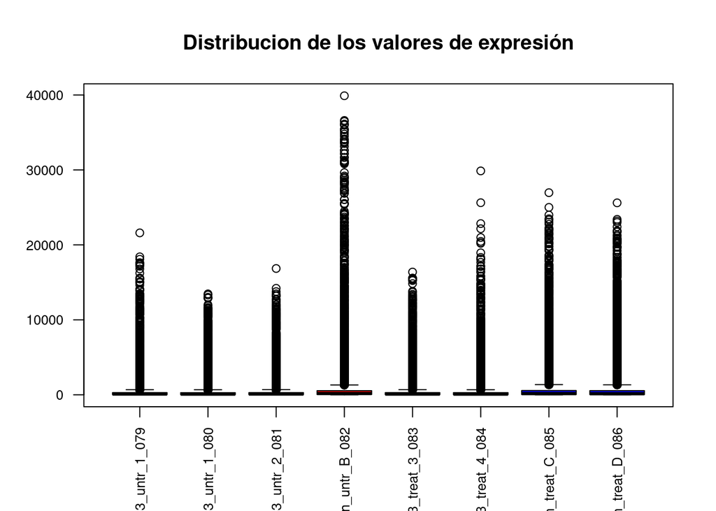

```r
boxplot(exprs(eSet), las=2, col=pData(eSet)$colores,
#        names=pData(eSet)$shortName,
        cex.axis=0.8, main="Distribucion de los valores de expresión")
```

Los datos son claramente asimétricos, lo que sugiere que puede tener sentido trabajar con los mismos datos en escala logarítmica.

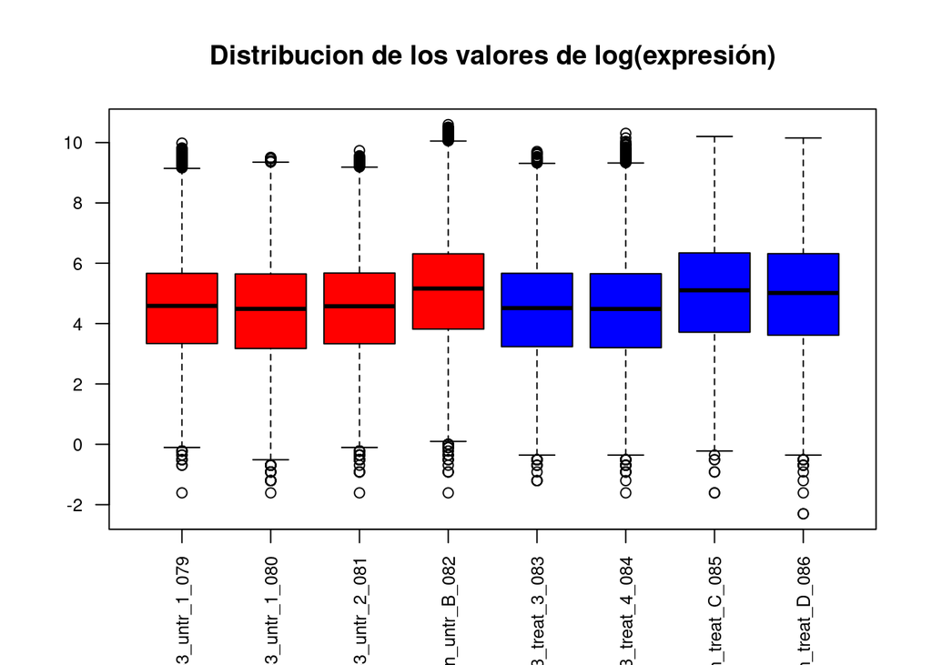

```r
boxplot(log(exprs(eSet)), las=2, col=pData(eSet)$colores,
#        names=pData(eSet)$shortName,
        cex.axis=0.8, main="Distribucion de los valores de log(expresión)")
```

Claramente, a la vista del segundo gráfico, **es mejor trabajar con los datos transformados logarítmicamente**

### 3.2.1 Exploración multivariante

Un análisis en componentes principales puede facilitar la visualización de los datos en dimensión reducida y, sobretodo, detectar posibles patrones que no se detecten a simple vista.

En primer lugar se realiza el cálculo de las componentes principales:

```r
resPC <- prcomp(t(exprs(eSet)))
summary(resPC)
```

```
Importance of components:
                             PC1       PC2       PC3       PC4       PC5
Standard deviation     9.607e+04 2.852e+04 1.760e+04 8.858e+03 8.195e+03
Proportion of Variance 8.732e-01 7.695e-02 2.929e-02 7.420e-03 6.350e-03
Cumulative Proportion  8.732e-01 9.502e-01 9.795e-01 9.869e-01 9.933e-01
                             PC6       PC7       PC8
Standard deviation     6.068e+03 5.864e+03 1.225e-10
Proportion of Variance 3.480e-03 3.250e-03 0.000e+00
Cumulative Proportion  9.968e-01 1.000e+00 1.000e+00
```

Para la visualización de los resultados podemos utilizar el paquete `ggfortify` que genera un gráfico en `ggplot` en función del objeto que se le proporcione.

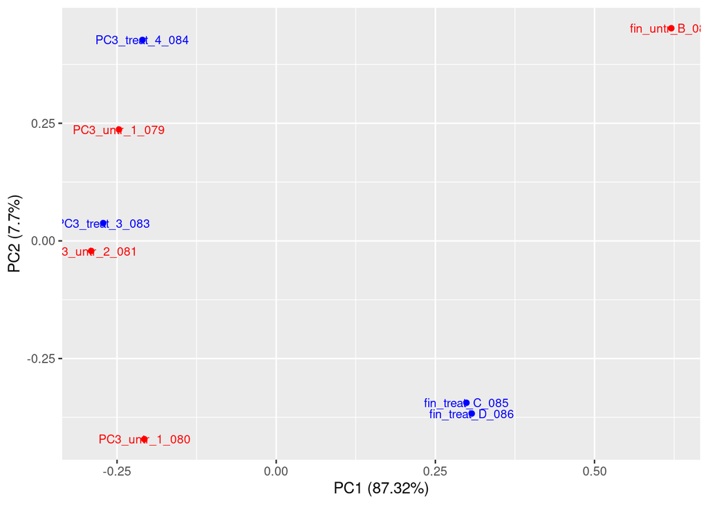

```r
if (!(require(ggfortify))) install.packages("ggfortify", dep = TRUE)
library(ggfortify)
autoplot(resPC, data = t(exprs(eSet)), label = TRUE, label.size = 3, colour = factor(pData(eSet)$colores))
```

El resultado muestra que, en contra de lo que uno podría esperar, lo que diferencia dos grupos es la característica “fin/PC3”, que se encuentra claramente asociada con la primera componente.

La diferencia entre tratados y no tratados no se asocia, al menos en el grupo PC3, con la segunda.

El diseño, además está desbalanceado, con lo que, en caso de querer realizar un estudio comparativo con los dos factores no se podría realizar en condiciones óptimas.

Esta visualización se confirma al realizar un cluster jerárquico y visualizarlo con un dendrograma

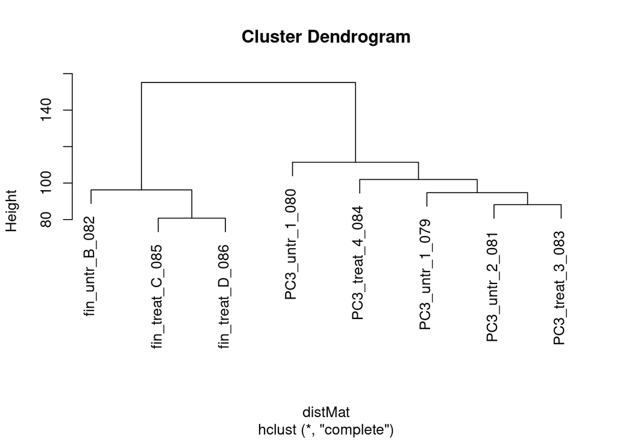

```r
distMat <- dist(t(log(exprs(eSet))))
hc <- hclust(distMat)
plot(hclust(distMat))
```

## 3.3 Discusión

El análisis exploratorio, realizado tras tomar logaritmo sobre los datos, ha puesto de manifiesto que existen dos fuentes de variación distintas. La mayor, relacionada con el origen de las muestras, no estaba especificada en el diseño del estudio. El efecto del tratamiento no aparece como la principal fuente de variabilidad lo que puede, probablemente, atribuirse a la confusión entre ambas fuentes.

Aparte de este problema inesperado, los datos no presentan evidencias de problemas: las distribuciones de las muestras son similares y no hay valores faltantes o cero, lo que se habría evidenciado al tomar logaritmos, por lo que en una situación real se procedería a investigar si es posible eliminar lo que aparenta ser un efecto batch y llevar a cabo el análisis.

# 4 Apéndice: Datasets

| GEO Dataset | GEO Serie | Especie | Título |
| --- | --- | --- | --- |
| GDS1251 | GSE2401 | Rattus norvegicus | Acute hypotension effect on kidneys |
| GDS1736 | GSE3737 | Homo sapiens | Arachidonic acid effect on prostate cancer cells |
| GDS2107 | GSE3311 | Rattus norvegicus | Long-term ethanol consumption effect on pancreas |
| GDS2153 | GSE5370 | Homo sapiens | Dermatomyositis |
| GDS2294 | GSE5583 | Mus musculus | Histone deacetylase 1 deficient embryonic stem cells |
| GDS2300 | GSE5668 | Mus musculus | Germinal vesicle stage and metaphase II stage oocyte comparison |
| GDS2406 | GSE6077 | Mus musculus | Proto-oncogene Nmyc overexpression effect on the embryonic lung |
| GDS2629 | GSE7381 | Mus musculus | Epithelial transcription factor Get-1 deficiency effect on embryonic skin |
| GDS2637 | GSE6299 | Rattus norvegicus | Keratinocyte cell line response to a (56)Fe ion beam |
| GDS2646 | GSE6868 | Gallus gallus | Homocysteine effect on cardiac neural crest cells |
| GDS2648 | GSE6766 | Mus musculus | Palmitate effect on myoblast cell line |
| GDS2686 | GSE6376 | Mus musculus | MyD88 deficient macrophage response to zymosan |
| GDS2698 | GSE6461 | Mus musculus | Synovial sarcoma model |
| GDS2699 | GSE6383 | Mus musculus | Mesenchymal and epithelial compartments of the developing intestine |
| GDS2707 | GSE4936 | Mus musculus | Neuralized embryoid bodies response to Hedgehog agonist |
| GDS2727 | GSE7196 | Mus musculus | Estrogen-related receptor alpha deficiency effect on the heart |
| GDS2744 | GSE7765 | Homo sapiens | Dioxin effect on breast cancer cell line (HG-U133A) |
| GDS2766 | GSE6850 | Mus musculus | Dominant negative cJun effect on apolipoprotein E deficient livers |
| GDS2855 | GSE3307 | Homo sapiens | Various muscle diseases (HG-U133B) |
| GDS2917 | GSE4734 | Mus musculus | Various brain regions of several inbred strains |
| GDS2922 | GSE5180 | Homo sapiens | Ascending aortic aneurysms |
| GDS2935 | GSE6281 | Homo sapiens | Allergic contact dermatitis: time course |
| GDS2936 | GSE8972 | Mus musculus | Neural retina leucine zipper deficiency effect on retinas: time course |
| GDS4843 | GSE42806 | Homo sapiens | Skeletal muscle disuse atrophy |
| GDS3221 | GSE6297 | Mus musculus | Liver response to human and chimpanzee diets |
| GDS3223 | GSE8853 | Homo sapiens | Interleukin-13 effect on esophageal epithelial cells from eosinophilic esophagitis patients |
| GDS781 | GSE1746 | Homo sapiens | CD14 cells from granulocyte colony stimulating factor mobilized peripheral blood: expression profile |
| GDS885 | GSE1417 | Homo sapiens | Tumor cell response to topoisomerase poison camptothecin |
| GDS2613 | GSE6955 | Homo sapiens | Rett syndrome: brain frontal cortex |

# 5 Apendice: Código R

*Para extraer el código R se ha utilizado la instrucción `knitr::purl("UOC-MU-AD0-2022-23-S1-PEC1-Solucion.Rmd")` que ha creado el archivo “UOC-MU-AD0-2022-23-S1-PEC1-Solución.R”. Dicho archivo se incluye automáticamente en un ultimo “chiunnk” de código. Para evitar que se ejecute, se asigna el valor FALSE a la opción “eval” del código*

```r
## ----setup, echo=FALSE--------------------------------------------------------------------------------------------------------------------
library(knitr)
library(rmdformats)

## Global options
options(max.print="75")
opts_chunk$set(echo=TRUE,
                 cache=FALSE,
               prompt=FALSE,
               tidy=TRUE,
               comment=NA,
               message=FALSE,
               warning=FALSE)
opts_knit$set(width=75)


## ----cargaDatasets------------------------------------------------------------------------------------------------------------------------
library(readxl)
GEOdat <- read_excel("GEOdatasets_updatedNov2022.xls")
GEOdat <- GEOdat[-27,]


## ----seleccionDatos-----------------------------------------------------------------------------------------------------------------------
set.seed (234567)
seleccion<- sample(1:nrow(GEOdat),1)
GEOSerie<- GEOdat[seleccion,2]
GEODataset <- GEOdat[seleccion,1]


## -----------------------------------------------------------------------------------------------------------------------------------------
library(GEOquery)
myGSE <- getGEO(GEOSerie, AnnotGPL=TRUE)
myGDS <- getGEO (GEODataset, AnnotGPL=TRUE)


## -----------------------------------------------------------------------------------------------------------------------------------------
Meta(myGDS)
Columns(myGDS)
Table(myGDS)


## -----------------------------------------------------------------------------------------------------------------------------------------
infoDF <- data.frame(matrix(rep(NA, 2*length(Meta(myGDS))), ncol=2))
for (i in 1:length(Meta(myGDS))){
  infoDF[i,1] =names(Meta(myGDS))[i]
  infoDF[i,2] =Meta(myGDS)[i]
}
colnames(infoDF) = c("Campo", "Descripción")
library(dplyr)
infoDF %>% kableExtra::kable() %>% kableExtra::kable_styling()


## -----------------------------------------------------------------------------------------------------------------------------------------
myeSet <- GDS2eSet(myGDS)
pData(myeSet) %>% kableExtra::kable() %>% kableExtra::kable_styling()


## -----------------------------------------------------------------------------------------------------------------------------------------
eSet <- myGSE[[1]]
class(eSet)


## -----------------------------------------------------------------------------------------------------------------------------------------
pData(eSet)[,c(1,8)]


## -----------------------------------------------------------------------------------------------------------------------------------------
shortName<- paste(substr(pData(eSet)$title,3,5),
                  c(rep("untr", 4), rep("treat",4)),
                    substr(pData(eSet)$title,1,1),
                    substr(rownames(pData(eSet)),6,8), sep="_")
colores<- c(rep("red", 4), rep("blue", 4))
pData(eSet)<- data.frame(shortName, colores, pData(eSet)[, c(1,8)])
colnames(exprs(eSet)) <- rownames(pData(eSet) ) <- pData(eSet)$shortName


## -----------------------------------------------------------------------------------------------------------------------------------------
boxplot(exprs(eSet), las=2, col=pData(eSet)$colores,
#        names=pData(eSet)$shortName,
        cex.axis=0.8, main="Distribucion de los valores de expresión")


## -----------------------------------------------------------------------------------------------------------------------------------------
boxplot(log(exprs(eSet)), las=2, col=pData(eSet)$colores,
#        names=pData(eSet)$shortName,
        cex.axis=0.8, main="Distribucion de los valores de log(expresión)")


## -----------------------------------------------------------------------------------------------------------------------------------------
resPC <- prcomp(t(exprs(eSet)))
summary(resPC)


## -----------------------------------------------------------------------------------------------------------------------------------------
if (!(require(ggfortify))) install.packages("ggfortify", dep=TRUE)
library(ggfortify)
autoplot(resPC, data=t(exprs(eSet)), label=TRUE, label.size=3, colour=factor(pData(eSet)$colores))


## -----------------------------------------------------------------------------------------------------------------------------------------
distMat <- dist(t(log(exprs(eSet))))
hc <-hclust(distMat)
plot(hclust(distMat))


## ---- echo=FALSE--------------------------------------------------------------------------------------------------------------------------
require(readxl)
library(magrittr)
GEOdatasets_updatedNov2022 <- read_excel("GEOdatasets_updatedNov2022.xls")
GEOdatasets_updatedNov2022 %>% kableExtra::kable() %>% kableExtra::kable_styling()


## ---- file="UOC-MU-AD0-2022-23-S1-PEC1-Solucion.R", eval=FALSE----------------------------------------------------------------------------
```

[^1]: La fecha de entrega es la que se indica en el enunciado de la PEC. En caso de no coincidir con la indicada en el aula, ésta será la que predomine.